# Esquisse Data Visualization Lab Key

First, make sure you install and load the `esquisse` package using `install.packages` and `library`:

```r
install.packages("esquisse")
install.packages("ggplot2")
```

```r
library(esquisse)
library(ggplot2)
```

1. Try creating a plot using the `Orange` data that automatically comes with R using the `esquisse` package. Recall that you need the `esquisser` function.
- Drag and drop the `age` variable to be plotted on the x-axis.
- Drag and drop the `circumference` variable to be plotted on the y-axis.
- What happens when you drag `tree` to the facet region of the esquisse GUI?
- What happens if you move this to color?
- Copy and paste the code from both options into the chunk below:

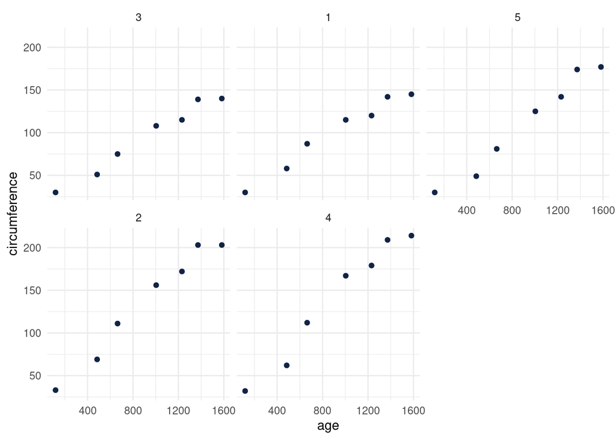

```r
# esquisser(Orange)
ggplot(Orange) +
  aes(x = age, y = circumference) +
  geom_point(shape = "circle", size = 1.5, colour = "#112446") +
  theme_minimal() +
  facet_wrap(vars(Tree))
```

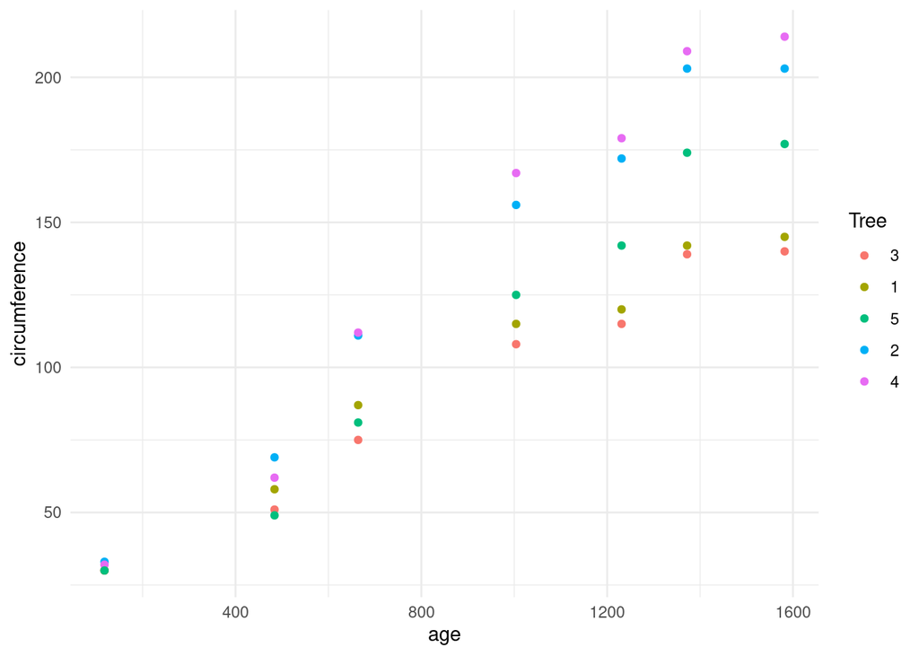

```r
ggplot(Orange) +
  aes(x = age, y = circumference, colour = Tree) +
  geom_point(shape = "circle", size = 1.5) +
  scale_color_hue(direction = 1) +
  theme_minimal()
```

2. Click where it says “point” (may say “auto” depending on how you did the last question) on the far left side and change the plot to a different type of plot. Copy and paste the code into the chunk below. Close Esquisse and run the chunk below to generate a ggplot.

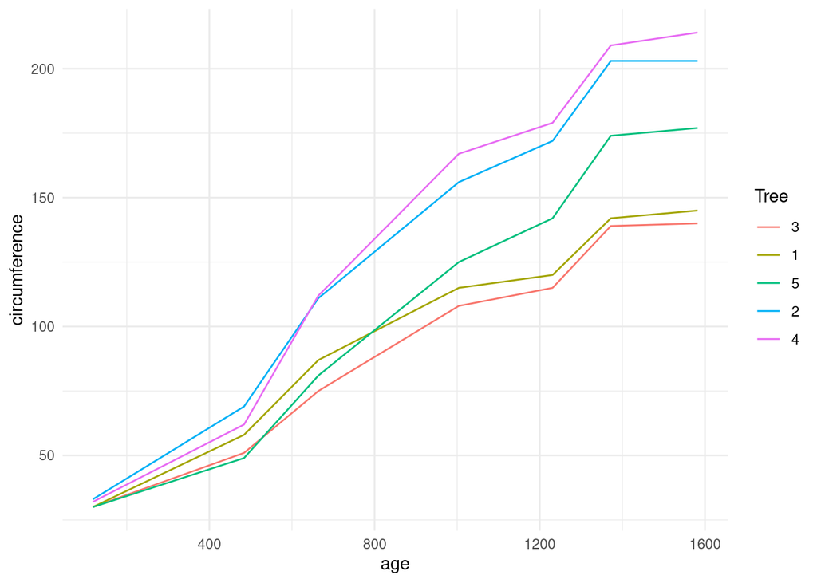

```r
ggplot(Orange) +
  aes(x = age, y = circumference, colour = Tree) +
  geom_line(size = 0.5) +
  scale_color_hue(direction = 1) +
  theme_minimal()
```

**Bonus / Extra practice**:

Launch Esquisse on any selection of the following datasets we have worked with before and explore!

```r
airquality
```

```
##     Ozone Solar.R Wind Temp Month Day
## 1      41     190  7.4   67     5   1
## 2      36     118  8.0   72     5   2
## 3      12     149 12.6   74     5   3
## 4      18     313 11.5   62     5   4
## 5      NA      NA 14.3   56     5   5
## 6      28      NA 14.9   66     5   6
## 7      23     299  8.6   65     5   7
## 8      19      99 13.8   59     5   8
## 9       8      19 20.1   61     5   9
## 10     NA     194  8.6   69     5  10
## 11      7      NA  6.9   74     5  11
## 12     16     256  9.7   69     5  12
## 13     11     290  9.2   66     5  13
## 14     14     274 10.9   68     5  14
```

[output cut: 139 more lines]

```r
iris
```

```
##     Sepal.Length Sepal.Width Petal.Length Petal.Width    Species
## 1            5.1         3.5          1.4         0.2     setosa
## 2            4.9         3.0          1.4         0.2     setosa
## 3            4.7         3.2          1.3         0.2     setosa
## 4            4.6         3.1          1.5         0.2     setosa
## 5            5.0         3.6          1.4         0.2     setosa
## 6            5.4         3.9          1.7         0.4     setosa
## 7            4.6         3.4          1.4         0.3     setosa
## 8            5.0         3.4          1.5         0.2     setosa
## 9            4.4         2.9          1.4         0.2     setosa
## 10           4.9         3.1          1.5         0.1     setosa
## 11           5.4         3.7          1.5         0.2     setosa
## 12           4.8         3.4          1.6         0.2     setosa
## 13           4.8         3.0          1.4         0.1     setosa
## 14           4.3         3.0          1.1         0.1     setosa
```

[output cut: 136 more lines]

```r
vacc <- read_csv("https://hutchdatascience.org/SeattleStatSummer_R/data/USA_covid19_vaccinations.csv")
bike <-read_csv("https://hutchdatascience.org/SeattleStatSummer_R/data/Bike_Lanes.csv")
state <- read_csv("https://hutchdatascience.org/SeattleStatSummer_R/data/states.csv")
#esquisser(state)
```